# Analisis Bibliometrik dengan R

# 1. Import and Screening the Data

[output not shown]

````r
```r
summary(results)
````

MAIN INFORMATION ABOUT DATA

Timespan 1966 : 2026 Sources (Journals, Books, etc) 1 Documents 7623 Annual Growth Rate % 1.82 Document Average Age 25.6 Average citations per doc 3.438 Average citations per year per doc 0.2612 References 1

DOCUMENT TYPES  
article 5636 conference paper 24 editorial 17 erratum 46 letter 873 note 575 review 297 short survey 155

DOCUMENT CONTENTS Keywords Plus (ID) 9 Author’s Keywords (DE) 3444

AUTHORS Authors 7432 Author Appearances 13140 Authors of single-authored docs 2364

AUTHORS COLLABORATION Single-authored docs 4775 Documents per Author 1.03 Co-Authors per Doc 1.72 International co-authorships % 4.014

Annual Scientific Production

Year Articles 1966 71 1967 105 1968 98 1969 114 1970 128 1971 101 1972 132 1973 124 1974 120 1975 123 1976 116 1977 120 1978 109 1979 102 1980 96 1981 90 1982 93 1983 93 1984 93 1985 80 1986 94 1987 84 1988 94 1989 96 1990 82 1991 89 1992 92 1993 75 1994 92 1995 96 1996 77 1997 84 1998 85 1999 75 2000 91 2001 81 2002 118 2003 147 2004 135 2005 124 2006 127 2007 135 2008 130 2009 129 2010 118 2011 151 2012 144 2013 137 2014 119 2015 123 2016 176 2017 183 2018 199 2019 188 2020 248 2021 227 2022 194 2023 167 2024 261 2025 238 2026 210

Annual Percentage Growth Rate 1.82

Most Productive Authors

Authors Articles Authors Articles Fractionalized 1 CROSS R 138 CROSS R 137.0 2 FEATONBY D 126 FEATONBY D 107.0 3 NA NA 71 NA NA 71.0 4 WILLIAMS G 47 TABER KS 45.3 5 TABER KS 46 WILLIAMS G 44.5 6 PENDRILL AM 42 THOMPSON F 35.0 7 WARREN JW 39 MARSHALL R 33.0 8 THOMPSON F 36 WARREN JW 32.8 9 RUIZ MJ 35 PARKER K 30.1 10 MARSHALL R 34 GLUCK P 26.7

Top manuscripts per citations

```r
                         Paper                                 DOI  TC TCperYear  NTC
```

1 STAACKS S, 2018, PHYS EDUC 10.1088/1361-6552/aac05e 262 29.11 42.3 2 HUGHES SW, 2005, PHYS EDUC 10.1088/0031-9120/40/5/008 245 11.14 46.0 3 MICHAEL WATTS D, 1983, PHYSICS EDUCATION 10.1088/0031-9120/18/5/307 206 4.68 54.0 4 HASAN S, 1999, PHYS EDUC 10.1088/0031-9120/34/5/304 180 6.43 26.5 5 OSBORNE RJ, 1980, PHYSICS EDUCATION 10.1088/0031-9120/15/6/312 159 3.38 40.8 6 VOLLMER M, 2004, PHYS EDUC 10.1088/0031-9120/39/1/006 155 6.74 37.9 7 WELLINGTON J, 1990, PHYSICS EDUCATION 10.1088/0031-9120/25/5/307 140 3.78 22.3 8 YEADON W, 2023, PHYS EDUC 10.1088/1361-6552/acc5cf 135 33.75 35.1 9 MCDERMOTT LC, 2000, PHYS EDUC 10.1088/0031-9120/35/6/306 117 4.33 10.3 10 WATTS DM, 1981, PHYSICS EDUCATION 10.1088/0031-9120/16/6/313 110 2.39 38.5

Corresponding Author’s Countries

```r
      Country Articles   Freq SCP MCP MCP_Ratio
```

1 UNITED KINGDOM 415 0.1579 390 25 0.0602 2 USA 298 0.1134 290 8 0.0268 3 AUSTRALIA 199 0.0757 190 9 0.0452 4 ITALY 139 0.0529 128 11 0.0791 5 INDIA 109 0.0415 107 2 0.0183 6 BRAZIL 106 0.0403 103 3 0.0283 7 GERMANY 98 0.0373 85 13 0.1327 8 TURKEY 91 0.0346 88 3 0.0330 9 SPAIN 69 0.0262 61 8 0.1159 10 INDONESIA 67 0.0255 64 3 0.0448

SCP: Single Country Publications

MCP: Multiple Country Publications

Total Citations per Country

```r
       Country      Total Citations Average Article Citations
```

1 UNITED KINGDOM 1679 4.046 2 USA 1111 3.728 3 GERMANY 835 8.520 4 AUSTRALIA 730 3.668 5 ITALY 554 3.986 6 SWEDEN 487 8.696 7 TURKEY 376 4.132 8 BRAZIL 283 2.670 9 SPAIN 279 4.043 10 ISRAEL 271 4.839

Most Relevant Sources

```r
 Sources        Articles
```

1 PHYSICS EDUCATION 7623

Most Relevant Keywords

Author Keywords (DE) Articles Keywords-Plus (ID) Articles 1 PHYSICS EDUCATION 112 NUCLEAR.POWER.PLANT 2 2 ARDUINO 75 HUMAN 1 3 SMARTPHONE 37 NORMAL.HUMAN 1 4 PHYSICS 25 NUCLEAR.SAFETY 1 5 TRACKER 23 POPULATION.EXPOSURE 1 6 VIDEO ANALYSIS 23 PREVENTION 1 7 STEM EDUCATION 22 RADIATION.EXPOSURE 1 8 PHYSICS TEACHING 21 RADIOISOTOPE 1 9 STEM 21 UNITED.KINGDOM 1 10 ACTIVE LEARNING 19 NA. NA

````r
```r
df <- Master

glimpse(df)
````

```
Rows: 7,623
Columns: 34
$ AU                <chr> "CROSS R", "PEER T;KAPON S", "PILI UB", "SARAOS CHA;SENADOS KM;HAMOY EN", "BISSELL JJ", "PAL SK;MONDAL P;SAMANTA SC", …
$ KW_Merged         <chr> "AVERAGE ACCELERATION; CONSTANT ACCELERATION; VARIABLE ACCELERATION", "HIGH SCHOOL; INQUIRY-BASED LEARNING; MAKER EDUC…
$ DE                <chr> "AVERAGE ACCELERATION; CONSTANT ACCELERATION; VARIABLE ACCELERATION", "HIGH SCHOOL; INQUIRY-BASED LEARNING; MAKER EDUC…
$ ID                <chr> NA, NA, NA, NA, NA, NA, NA, NA, NA, NA, NA, NA, NA, NA, NA, NA, NA, NA, NA, NA, NA, NA, NA, NA, NA, NA, NA, NA, NA, NA…
$ C1                <chr> "SCHOOL OF PHYSICS, UNIVERSITY OF SYDNEY, SYDNEY, 2006, NSW, AUSTRALIA", "FACULTY OF EDUCATION IN SCIENCE AND TECHNOLO…
$ JI                <chr> "PHYS. EDUC.", "PHYS. EDUC.", "PHYS. EDUC.", "PHYS. EDUC.", "PHYS. EDUC.", "PHYS. EDUC.", "PHYS. EDUC.", "PHYS. EDUC."…
$ AB                <chr> "THE AVERAGE ACCELERATION OF A CAR OR A SPRINT RUNNER CAN BE ESTIMATED FROM THE TIME TAKEN TO TRAVEL A GIVEN DISTANCE.…
$ RP                <chr> "R. CROSS; SCHOOL OF PHYSICS, UNIVERSITY OF SYDNEY, SYDNEY, 2006, AUSTRALIA; EMAIL: RODNEY.CROSS@SYDNEY.EDU.AU", "S. K…
$ DI                <chr> "10.1088/1361-6552/adb6eb", "10.1088/1361-6552/ae0d26", "10.1088/1361-6552/ad6c9b", "10.1088/1361-6552/ae806b", "10.10…
$ SN                <chr> "00319120", "00319120", "00319120", "00319120", "00319120", "00319120", "00319120", "00319120", "00319120", "00319120"…
$ SO                <chr> "PHYSICS EDUCATION", "PHYSICS EDUCATION", "PHYSICS EDUCATION", "PHYSICS EDUCATION", "PHYSICS EDUCATION", "PHYSICS EDUC…
$ LA                <chr> "ENGLISH", "ENGLISH", "ENGLISH", "ENGLISH", "ENGLISH", "ENGLISH", "ENGLISH", "ENGLISH", "ENGLISH", "ENGLISH", "ENGLISH…
$ TC                <dbl> 0, 0, 2, 0, 0, 0, 0, 0, 1, 0, 0, 0, 0, 0, 0, 0, 1, 0, 0, 1, 0, 0, 0, 0, 0, 1, 4, 1, 0, 0, 2, 1, 0, 0, 2, 3, 1, 1, 0, 0…
```

[output cut: 21 more lines]

```r
table(df$DT)
```

[output not shown]

```r
df <- df |> filter(`DT` %in% c("ARTICLE", "LETTER", "NOTE", "REVIEW", "SHORT SURVEY"))
n_secondclean <- nrow(df)
glimpse(df)
```

```
Rows: 7,536
Columns: 34
$ AU                <chr> "CROSS R", "PEER T;KAPON S", "PILI UB", "SARAOS CHA;SENADOS KM;HAMOY EN", "BISSELL JJ", "PAL SK;MONDAL P;SAMANTA SC", …
$ KW_Merged         <chr> "AVERAGE ACCELERATION; CONSTANT ACCELERATION; VARIABLE ACCELERATION", "HIGH SCHOOL; INQUIRY-BASED LEARNING; MAKER EDUC…
$ DE                <chr> "AVERAGE ACCELERATION; CONSTANT ACCELERATION; VARIABLE ACCELERATION", "HIGH SCHOOL; INQUIRY-BASED LEARNING; MAKER EDUC…
$ ID                <chr> NA, NA, NA, NA, NA, NA, NA, NA, NA, NA, NA, NA, NA, NA, NA, NA, NA, NA, NA, NA, NA, NA, NA, NA, NA, NA, NA, NA, NA, NA…
$ C1                <chr> "SCHOOL OF PHYSICS, UNIVERSITY OF SYDNEY, SYDNEY, 2006, NSW, AUSTRALIA", "FACULTY OF EDUCATION IN SCIENCE AND TECHNOLO…
$ JI                <chr> "PHYS. EDUC.", "PHYS. EDUC.", "PHYS. EDUC.", "PHYS. EDUC.", "PHYS. EDUC.", "PHYS. EDUC.", "PHYS. EDUC.", "PHYS. EDUC."…
$ AB                <chr> "THE AVERAGE ACCELERATION OF A CAR OR A SPRINT RUNNER CAN BE ESTIMATED FROM THE TIME TAKEN TO TRAVEL A GIVEN DISTANCE.…
$ RP                <chr> "R. CROSS; SCHOOL OF PHYSICS, UNIVERSITY OF SYDNEY, SYDNEY, 2006, AUSTRALIA; EMAIL: RODNEY.CROSS@SYDNEY.EDU.AU", "S. K…
$ DI                <chr> "10.1088/1361-6552/adb6eb", "10.1088/1361-6552/ae0d26", "10.1088/1361-6552/ad6c9b", "10.1088/1361-6552/ae806b", "10.10…
$ SN                <chr> "00319120", "00319120", "00319120", "00319120", "00319120", "00319120", "00319120", "00319120", "00319120", "00319120"…
$ SO                <chr> "PHYSICS EDUCATION", "PHYSICS EDUCATION", "PHYSICS EDUCATION", "PHYSICS EDUCATION", "PHYSICS EDUCATION", "PHYSICS EDUC…
$ LA                <chr> "ENGLISH", "ENGLISH", "ENGLISH", "ENGLISH", "ENGLISH", "ENGLISH", "ENGLISH", "ENGLISH", "ENGLISH", "ENGLISH", "ENGLISH…
$ TC                <dbl> 0, 0, 2, 0, 0, 0, 0, 0, 1, 0, 0, 0, 0, 0, 0, 0, 1, 0, 0, 1, 0, 0, 0, 0, 0, 1, 4, 1, 0, 0, 2, 1, 0, 0, 2, 3, 1, 1, 0, 0…
```

[output cut: 21 more lines]

```r
sum(is.na(df$AU))
```

```
[1] 0
```

```r
sum(is.na(df$AU_UN))
```

```
[1] 1225
```

```r
n_thirdclean <- n_secondclean - sum(is.na(df$AU_UN))
n_thirdclean
```

```
[1] 6311
```

```r
unreported_year <- df %>%
  group_by(PY) %>%
  summarise(
    Total = n(),
    Unreported = sum(AU_UN == "UNREPORTED", na.rm = TRUE),
    Percent = 100 * Unreported / Total
  )

unreported_year
```

| PY | Total | Unreported | Percent |
| --- | --- | --- | --- |
| 1966 | 66 | 0 | 0 |
| 1967 | 96 | 0 | 0 |
| 1968 | 98 | 0 | 0 |
| 1969 | 114 | 0 | 0 |
| 1970 | 126 | 0 | 0 |
| 1971 | 96 | 0 | 0 |
| 1972 | 128 | 0 | 0 |
| 1973 | 120 | 0 | 0 |
| 1974 | 120 | 0 | 0 |
| 1975 | 123 | 0 | 0 |

[output cut: 51 more lines]

```r
unreported_year <- df |>
  filter(is.na(AU_UN) | AU_UN == "") |>
  count(PY, name = "Unreported")

total_year <- df |>
  count(PY, name = "Total")

unreported_pct <- total_year |>
  left_join(unreported_year, by = "PY") |>
  mutate(
    Unreported = ifelse(is.na(Unreported), 0, Unreported),
    Percent = Unreported / Total * 100
  )
```

Annual percentage of records with unreported affiliation.

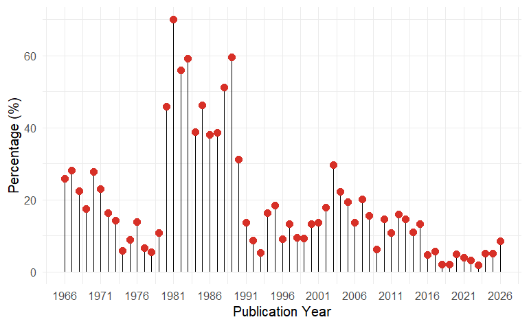

```r
ggplot(
  unreported_pct,
  aes(PY, Percent)
) +
  geom_segment(
    aes(
      xend = PY,
      y = 0,
      yend = Percent
    ),
    colour = "black"
  ) +
  geom_point(
    colour = "#d73027",
    size = 3
  ) +
  labs(
    x = "Publication Year",
    y = "Percentage (%)"
  ) +
  theme_minimal(base_size = 14) +
  scale_x_continuous(
    breaks = seq(1966, 2026, 5)
  )
```

```r
prisma_table <- tibble(
  Stage = c(
    "Records identified",
    "Removed: Duplicated documents",
    "Removed: Conference Paper, Editorial, Erratum",
    "Removed: Missing Affiliations",
    "Final dataset"
  ),
  N = c(
    n_master,
    n_firstclean,
    n_secondclean,
    n_thirdclean,
    n_thirdclean
  )
)

prisma_table
```

| Stage | N |
| --- | --- |
| Records identified | 7709 |
| Removed: Duplicated documents | 7623 |
| Removed: Conference Paper, Editorial, Erratum | 7536 |
| Removed: Missing Affiliations | 6311 |
| Final dataset | 6311 |

```r
loss_summary <- tibble(
  Initial = n_master,
  Final = n_thirdclean,
  Removed = n_master - n_thirdclean,
  Removal_Percent = round(
    (n_master - n_thirdclean) / n_master * 100,
    2
  )
)

loss_summary
```

| Initial | Final | Removed | Removal_Percent |
| --- | --- | --- | --- |
| 7709 | 6311 | 1398 | 18.13 |

Missing data on each column.

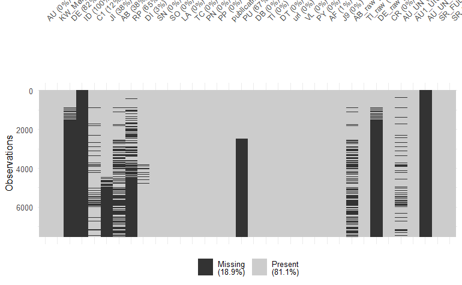

```r
library(naniar)

vis_miss(
  df
)
```

```r
glimpse(df)
```

```
Rows: 7,536
Columns: 34
$ AU                <chr> "CROSS R", "PEER T;KAPON S", "PILI UB", "SARAOS CHA;SENADOS KM;HAMOY EN", "BISSELL JJ", "PAL SK;MONDAL P;SAMANTA SC", …
$ KW_Merged         <chr> "AVERAGE ACCELERATION; CONSTANT ACCELERATION; VARIABLE ACCELERATION", "HIGH SCHOOL; INQUIRY-BASED LEARNING; MAKER EDUC…
$ DE                <chr> "AVERAGE ACCELERATION; CONSTANT ACCELERATION; VARIABLE ACCELERATION", "HIGH SCHOOL; INQUIRY-BASED LEARNING; MAKER EDUC…
$ ID                <chr> NA, NA, NA, NA, NA, NA, NA, NA, NA, NA, NA, NA, NA, NA, NA, NA, NA, NA, NA, NA, NA, NA, NA, NA, NA, NA, NA, NA, NA, NA…
$ C1                <chr> "SCHOOL OF PHYSICS, UNIVERSITY OF SYDNEY, SYDNEY, 2006, NSW, AUSTRALIA", "FACULTY OF EDUCATION IN SCIENCE AND TECHNOLO…
$ JI                <chr> "PHYS. EDUC.", "PHYS. EDUC.", "PHYS. EDUC.", "PHYS. EDUC.", "PHYS. EDUC.", "PHYS. EDUC.", "PHYS. EDUC.", "PHYS. EDUC."…
$ AB                <chr> "THE AVERAGE ACCELERATION OF A CAR OR A SPRINT RUNNER CAN BE ESTIMATED FROM THE TIME TAKEN TO TRAVEL A GIVEN DISTANCE.…
$ RP                <chr> "R. CROSS; SCHOOL OF PHYSICS, UNIVERSITY OF SYDNEY, SYDNEY, 2006, AUSTRALIA; EMAIL: RODNEY.CROSS@SYDNEY.EDU.AU", "S. K…
$ DI                <chr> "10.1088/1361-6552/adb6eb", "10.1088/1361-6552/ae0d26", "10.1088/1361-6552/ad6c9b", "10.1088/1361-6552/ae806b", "10.10…
$ SN                <chr> "00319120", "00319120", "00319120", "00319120", "00319120", "00319120", "00319120", "00319120", "00319120", "00319120"…
$ SO                <chr> "PHYSICS EDUCATION", "PHYSICS EDUCATION", "PHYSICS EDUCATION", "PHYSICS EDUCATION", "PHYSICS EDUCATION", "PHYSICS EDUC…
$ LA                <chr> "ENGLISH", "ENGLISH", "ENGLISH", "ENGLISH", "ENGLISH", "ENGLISH", "ENGLISH", "ENGLISH", "ENGLISH", "ENGLISH", "ENGLISH…
$ TC                <dbl> 0, 0, 2, 0, 0, 0, 0, 0, 1, 0, 0, 0, 0, 0, 0, 0, 1, 0, 0, 1, 0, 0, 0, 0, 0, 1, 4, 1, 0, 0, 2, 1, 0, 0, 2, 3, 1, 1, 0, 0…
```

[output cut: 21 more lines]

PRISMA Diagram of the Screening Process

```r
library(DiagrammeR)

grViz(sprintf("
digraph prisma {

graph [layout = dot, rankdir = TB]

node [
shape = box,
style = filled,
fillcolor = lightblue,
fontname = Helvetica
]

A [label='Records identified in \n Scopus database\n(n = %s)']

B [label='Duplicate records removed\n(n = %s)']

C [label='First screening removal\n(n = %s)']

D [label='Conference papers, editorials,\nerrata removed (n = %s)']

E [label='Second screening removal\n(n = %s)']

F [label='Missing affiliations and \n incomplete abstract removed\n(n = %s)']

G [label='Final dataset included\nfor analysis\n(n = %s)']

A -> B
A -> C
C -> D
C -> E
E -> F
E -> G
}
",
n_master,
n_master - n_firstclean,
n_firstclean,
n_firstclean - n_secondclean,
n_secondclean,
n_secondclean - n_thirdclean,
n_thirdclean
))
```

[interactive chart not shown]

# RQ 1 (Number of Publication between 1966 and 2026)

```r
df_clean <- read_csv(
  "PhysicsEducation_Cleaned.csv",
  show_col_types = FALSE
)

pub_year <- Master %>%
  count(PY, name = "N_Papers") %>%
  arrange(PY)

pub_year
```

| PY | N_Papers |
| --- | --- |
| 1966 | 71 |
| 1967 | 105 |
| 1968 | 98 |
| 1969 | 114 |
| 1970 | 128 |
| 1971 | 101 |
| 1972 | 132 |
| 1973 | 124 |
| 1974 | 120 |
| 1975 | 123 |

[output cut: 51 more lines]

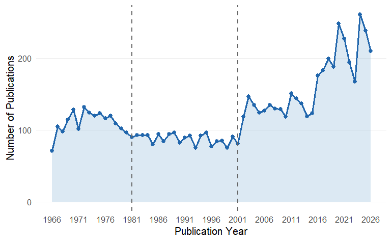

```r
library(ggplot2)
library(zoo)

pub_year$MA5 <- rollmean(
  pub_year$N_Papers,
  k = 5,
  fill = NA,
  align = "center"
)

ggplot(pub_year, aes(PY, N_Papers)) +

  geom_area(
    fill = "#74a9cf",
    alpha = 0.25
  ) +

  geom_line(
    colour = "#2166ac",
    linewidth = 1.2,
    na.rm = TRUE
  ) +

  geom_point(
    colour = "#2166ac",
    size = 2
  ) +

  geom_vline(
    xintercept = c(1981, 2001),
    linetype = "dashed",
    colour = "grey40",
    linewidth = 0.7
  ) +

  labs(
    x = "Publication Year",
    y = "Number of Publications"
  ) +

  scale_x_continuous(
    breaks = seq(1966, 2026, 5)
  ) +

  theme_minimal(base_size = 14) +

  theme(
    plot.title = element_text(
      size = 18,
      face = "bold"
    ),
    plot.subtitle = element_text(
      size = 12,
      colour = "grey40"
    ),
    panel.grid.minor = element_blank(),
    panel.grid.major.x = element_blank()
  )
```

```r
pub_year <- pub_year %>%
  mutate(
    Growth_Rate =
      (N_Papers - lag(N_Papers)) /
      lag(N_Papers) * 100
  )

pub_year %>%
  arrange(desc(Growth_Rate)) %>%
  select(
    PY,
    N_Papers,
    Growth_Rate
  ) %>%
  head(10)
```

|  | PY | N_Papers | Growth_Rate |
| --- | --- | --- | --- |
| 1 | 2024 | 261 | 56.28743 |
| 2 | 1967 | 105 | 47.88732 |
| 3 | 2002 | 118 | 45.67901 |
| 4 | 2016 | 176 | 43.08943 |
| 5 | 2020 | 248 | 31.91489 |
| 6 | 1972 | 132 | 30.69307 |
| 7 | 2011 | 151 | 27.96610 |
| 8 | 2003 | 147 | 24.57627 |
| 9 | 1994 | 92 | 22.66667 |
| 10 | 2000 | 91 | 21.33333 |

# RQ2 (Contribution Trends of Countries and Institutions between 1966 and 2026)

| Country | n |
| --- | --- |
| UNITED KINGDOM | 2654 |
| UNITED STATES | 518 |
| AUSTRALIA | 283 |
| ITALY | 249 |
| BRAZIL | 177 |
| INDIA | 162 |
| GERMANY | 151 |
| TURKEY | 112 |
| SPAIN | 106 |
| INDONESIA | 95 |

[output cut: 104 more lines]

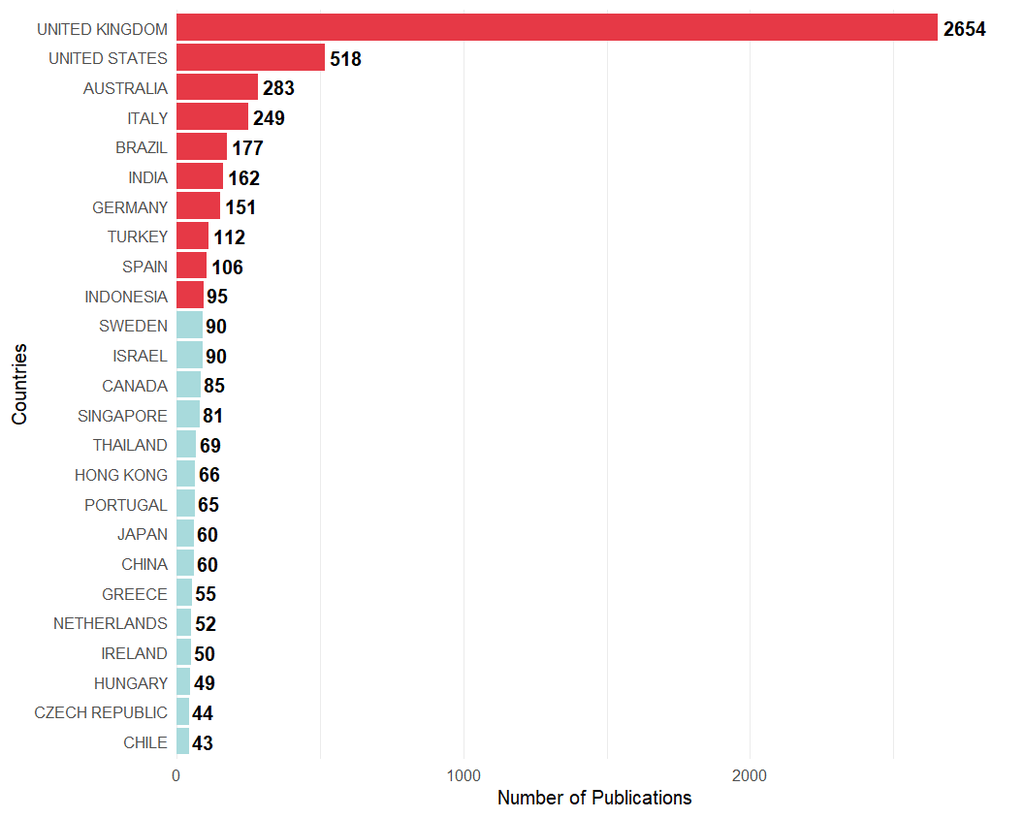

```r
count_prod <- df_clean %>%
  mutate(ID = row_number()) %>%
  filter(
    Country != "NA"
  ) %>%
  distinct(ID, Country) %>%
  count(Country, sort = TRUE)

top25_count <- count_prod %>%
  slice(1:25)

top25_count <- top25_count %>%
  mutate(
    Share = round(
      n / sum(n) * 100,
      2
    )
  )

top25_count2 <- top25_count %>%
  arrange(desc(n)) %>%
  mutate(
    group = ifelse(
      row_number() <= 10,
      "Top 5",
      "Others"
    )
  )

ggplot(
  top25_count2,
  aes(
    reorder(Country, n),
    n,
    fill = group
  )
) +
  geom_col() +
  geom_text(
    aes(label = n),
    hjust = -0.15,
    fontface = "bold"
  ) +
  coord_flip() +
  scale_fill_manual(
    values = c(
      "Top 5" = "#E63946",
      "Others" = "#A8DADC"
    )
  ) +
  scale_y_continuous(
    expand = expansion(mult = c(0, 0.1))
  ) +
  labs(
    x = "Countries",
    y = "Number of Publications"
  ) +
  theme_minimal(base_size = 14) +
  theme(
    legend.position = "none",
    legend.title = element_blank(),
    plot.title = element_text(
      face = "bold",
      size = 18
    ),
    panel.grid.major.y = element_blank()
  )
```

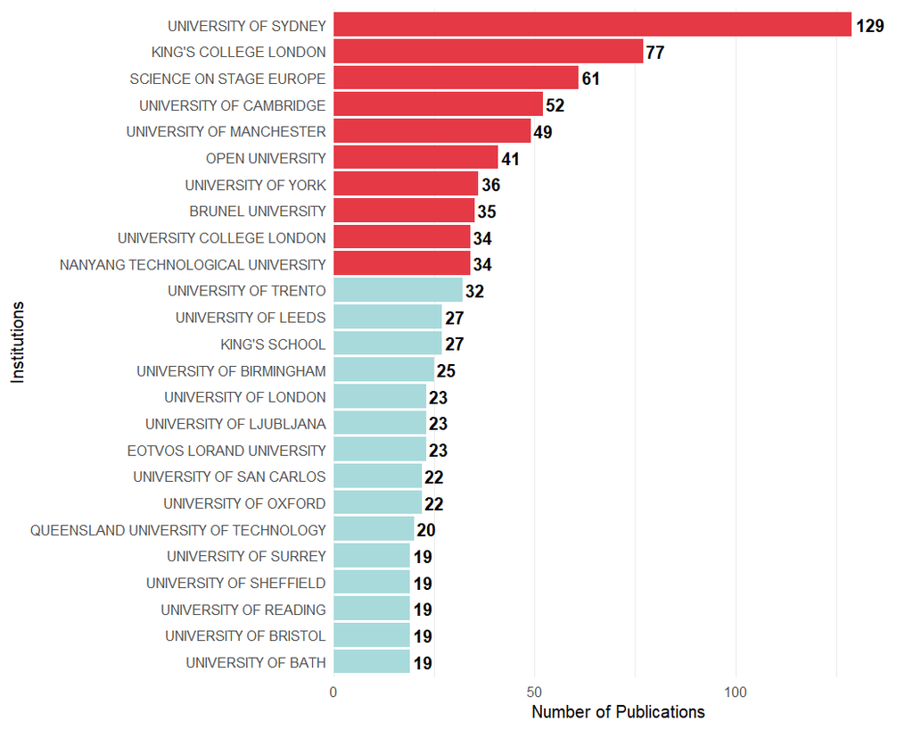

```r
top_inst <- df_clean %>%
  select(AU_UN) %>%
  filter(
    !is.na(AU_UN),
    AU_UN != "",
    AU_UN != "NOTREPORTED"
  ) %>%
  count(AU_UN, sort = TRUE) %>%
  slice_head(n = 25)

inst_prod <- df_clean %>%
  mutate(ID = row_number()) %>%
  filter(
    !is.na(AU_UN),
    AU_UN != "",
    AU_UN != "NOTREPORTED"
  ) %>%
  distinct(ID, AU_UN) %>%
  count(AU_UN, sort = TRUE)

top25_inst <- inst_prod %>%
  slice(1:25)

top25_inst <- top25_inst %>%
  mutate(
    Share = round(
      n / sum(n) * 100,
      2
    )
  )

top25_inst2 <- top25_inst %>%
  arrange(desc(n)) %>%
  mutate(
    group = ifelse(
      row_number() <= 10,
      "Top 5",
      "Others"
    )
  )

ggplot(
  top25_inst2,
  aes(
    reorder(AU_UN, n),
    n,
    fill = group
  )
) +
  geom_col() +
  geom_text(
    aes(label = n),
    hjust = -0.15,
    fontface = "bold"
  ) +
  coord_flip() +
  scale_fill_manual(
    values = c(
      "Top 5" = "#E63946",
      "Others" = "#A8DADC"
    )
  ) +
  scale_y_continuous(
    expand = expansion(mult = c(0, 0.1))
  ) +
  labs(
    x = "Institutions",
    y = "Number of Publications"
  ) +
  theme_minimal(base_size = 14) +
  theme(
    legend.position = "none",
    legend.title = element_blank(),
    plot.title = element_text(
      face = "bold",
      size = 18
    ),
    panel.grid.major.y = element_blank()
  )
```

# RQ3 (Citation and Impact Trends of Countries and Institutions between 1966 and 2026)

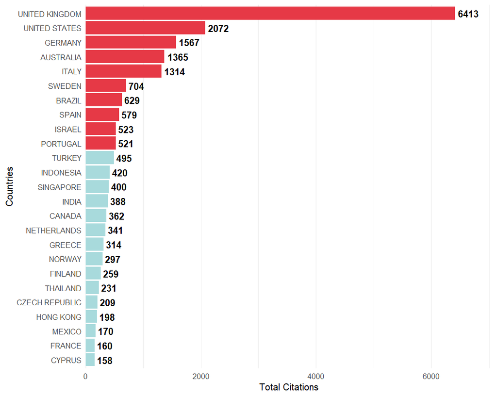

```r
df_clean <- df_clean %>%
  mutate(
    Citations =
      as.numeric(TC)
  )

count_citations <- df_clean %>%
  group_by(Country) %>%
  summarise(
    Publications = n(),

    Total_Citations =
      sum(
        Citations,
        na.rm = TRUE
      ),

    Mean_Citations =
      mean(
        Citations,
        na.rm = TRUE
      ),

    .groups = "drop"
  ) %>%
  arrange(
    desc(Total_Citations)
  )

top25_cited_count <- count_citations %>%
  slice_head(n = 25)

top25_cited_count2 <- top25_cited_count %>%
  arrange(desc(Total_Citations)) %>%
  mutate(
    group = ifelse(
      row_number() <= 10,
      "Top 5",
      "Others"
    )
  )

ggplot(
  top25_cited_count2,
  aes(
    reorder(Country, Total_Citations),
    Total_Citations,
    fill = group
  )
) +
  geom_col() +
  geom_text(
    aes(label = Total_Citations),
    hjust = -0.15,
    fontface = "bold"
  ) +
  coord_flip() +
  scale_fill_manual(
    values = c(
      "Top 5" = "#E63946",
      "Others" = "#A8DADC"
    )
  ) +
  scale_y_continuous(
    expand = expansion(mult = c(0, 0.1))
  ) +
  labs(
    x = "Countries",
    y = "Total Citations"
  ) +
  theme_minimal(base_size = 14) +
  theme(
    legend.position = "none",
    legend.title = element_blank(),
    plot.title = element_text(
      face = "bold",
      size = 18
    ),
    panel.grid.major.y = element_blank()
  )
```

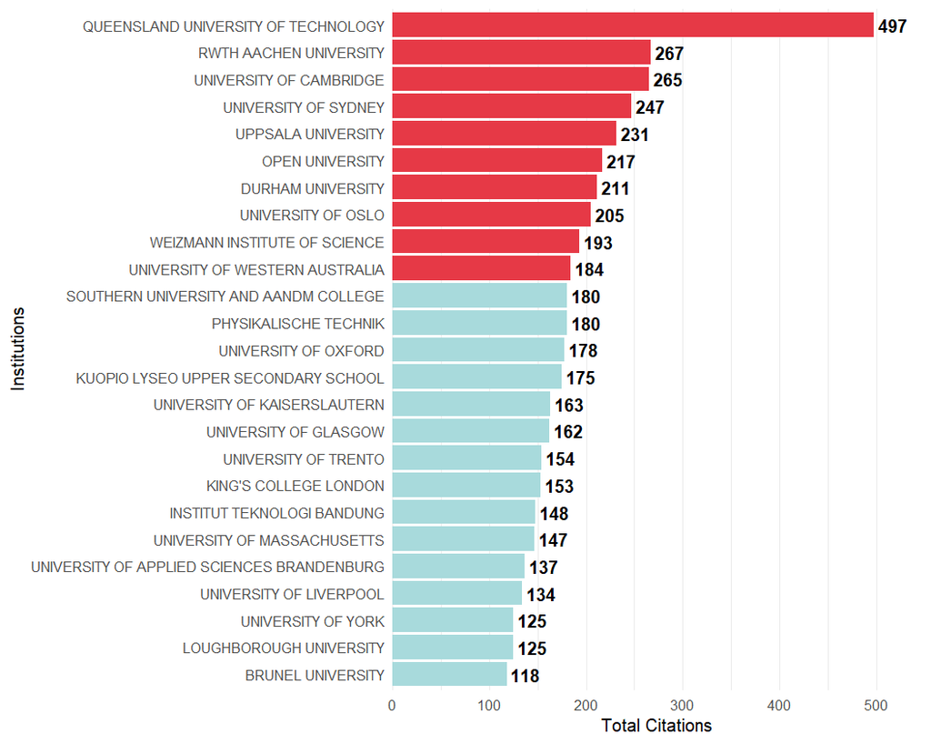

```r
df_clean <- read_csv(
  "PhysicsEducation_Cleaned.csv",
  show_col_types = FALSE
)

df_clean <- df_clean %>%
  mutate(
    Citations =
      as.numeric(TC)
  )

inst_citations <- df_clean %>%
  group_by(AU_UN) %>%
  summarise(
    Publications = n(),

    Total_Citations =
      sum(
        Citations,
        na.rm = TRUE
      ),

    Mean_Citations =
      mean(
        Citations,
        na.rm = TRUE
      ),

    .groups = "drop"
  ) %>%
  arrange(
    desc(Total_Citations)
  )

top25_cited_inst <- inst_citations %>%
  slice_head(n = 25)

top25_cited_inst2 <- top25_cited_inst %>%
  arrange(desc(Total_Citations)) %>%
  mutate(
    group = ifelse(
      row_number() <= 10,
      "Top 5",
      "Others"
    )
  )

ggplot(
  top25_cited_inst2,
  aes(
    reorder(AU_UN, Total_Citations),
    Total_Citations,
    fill = group
  )
) +
  geom_col() +
  geom_text(
    aes(label = Total_Citations),
    hjust = -0.15,
    fontface = "bold"
  ) +
  coord_flip() +
  scale_fill_manual(
    values = c(
      "Top 5" = "#E63946",
      "Others" = "#A8DADC"
    )
  ) +
  scale_y_continuous(
    expand = expansion(mult = c(0, 0.1))
  ) +
  labs(
    x = "Institutions",
    y = "Total Citations"
  ) +
  theme_minimal(base_size = 14) +
  theme(
    legend.position = "none",
    legend.title = element_blank(),
    plot.title = element_text(
      face = "bold",
      size = 18
    ),
    panel.grid.major.y = element_blank()
  )
```

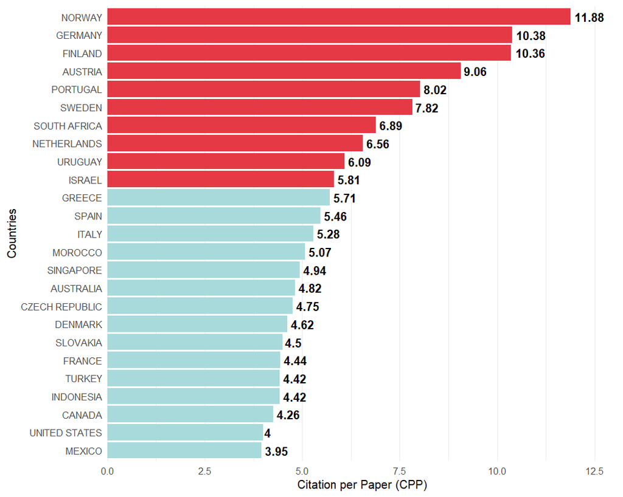

```r
count_citations <- count_citations %>%
  mutate(
    CPP =
      round(
        Total_Citations /
        Publications,
        2
      )
  )

high_impact <- count_citations %>%
  filter(
    Publications >= 10
  ) %>%
  arrange(
    desc(CPP)
  ) %>% slice_head(n = 25)


high_impact2 <- high_impact %>%
  arrange(desc(CPP)) %>%
  mutate(
    group = ifelse(
      row_number() <= 10,
      "Top 10",
      "Others"
    )
  )

ggplot(
  high_impact2,
  aes(
    reorder(Country, CPP),
    CPP,
    fill = group
  )
) +
  geom_col() +
  geom_text(
    aes(label = CPP),
    hjust = -0.15,
    fontface = "bold"
  ) +
  coord_flip() +
  scale_fill_manual(
    values = c(
      "Top 10" = "#E63946",
      "Others" = "#A8DADC"
    )
  ) +
  scale_y_continuous(
    expand = expansion(mult = c(0, 0.1))
  ) +
  labs(
    x = "Countries",
    y = "Citation per Paper (CPP)"
  ) +
  theme_minimal(base_size = 14) +
  theme(
    legend.position = "none",
    legend.title = element_blank(),
    plot.title = element_text(
      face = "bold",
      size = 18
    ),
    panel.grid.major.y = element_blank()
  )
```

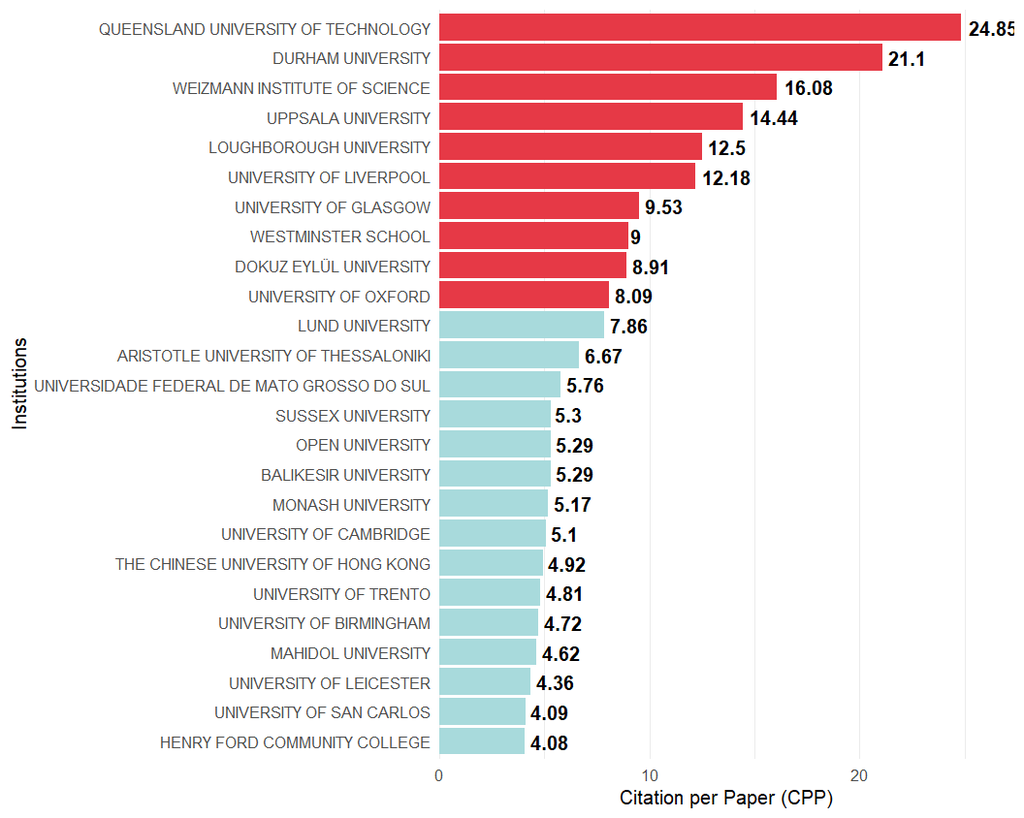

```r
inst_citations <- inst_citations %>%
  mutate(
    CPP =
      round(
        Total_Citations /
        Publications,
        2
      )
  )

high_impact <- inst_citations %>%
  filter(
    Publications >= 10
  ) %>%
  arrange(
    desc(CPP)
  ) %>% slice_head(n = 25)


high_impact2 <- high_impact %>%
  arrange(desc(CPP)) %>%
  mutate(
    group = ifelse(
      row_number() <= 10,
      "Top 5",
      "Others"
    )
  )

ggplot(
  high_impact2,
  aes(
    reorder(AU_UN, CPP),
    CPP,
    fill = group
  )
) +
  geom_col() +
  geom_text(
    aes(label = CPP),
    hjust = -0.15,
    fontface = "bold"
  ) +
  coord_flip() +
  scale_fill_manual(
    values = c(
      "Top 5" = "#E63946",
      "Others" = "#A8DADC"
    )
  ) +
  scale_y_continuous(
    expand = expansion(mult = c(0, 0.1))
  ) +
  labs(
    x = "Institutions",
    y = "Citation per Paper (CPP)"
  ) +
  theme_minimal(base_size = 14) +
  theme(
    legend.position = "none",
    legend.title = element_blank(),
    plot.title = element_text(
      face = "bold",
      size = 18
    ),
    panel.grid.major.y = element_blank()
  )
```

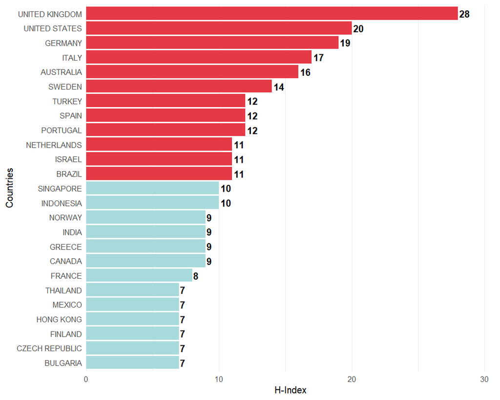

```r
country_h <- df_clean %>%
  group_by(Country) %>%
  summarise(
    H = {
      x <- sort(Citations, decreasing = TRUE)
      sum(x >= seq_along(x))
    }
  ) %>%
  arrange(desc(H)) %>%
  slice_head(n = 25) %>%
  mutate(
    group = ifelse(
      H >= 11,
      "Top 10",
      "Others"
    )
  )

ggplot(
  country_h,
  aes(
    reorder(Country, H),
    H,
    fill = group
  )
) +
  geom_col() +
  geom_text(
    aes(label = H),
    hjust = -0.15,
    fontface = "bold"
  ) +
  coord_flip() +
  scale_fill_manual(
    values = c(
      "Top 10" = "#E63946",
      "Others" = "#A8DADC"
    )
  ) +
  scale_y_continuous(
    expand = expansion(mult = c(0, 0.1))
  ) +
  labs(
    x = "Countries",
    y = "H-Index"
  ) +
  theme_minimal(base_size = 14) +
  theme(
    legend.position = "none",
    legend.title = element_blank(),
    plot.title = element_text(
      face = "bold",
      size = 18
    ),
    panel.grid.major.y = element_blank()
  )
```

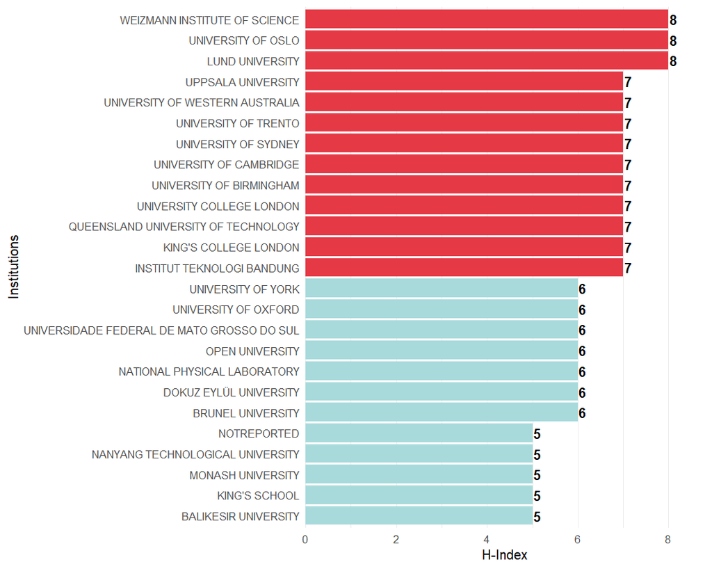

```r
affil_h <- df_clean %>%
  group_by(AU_UN) %>%
  summarise(
    H = {
      x <- sort(Citations, decreasing = TRUE)
      sum(x >= seq_along(x))
    }
  ) %>%
  arrange(desc(H)) %>%
  slice_head(n = 25) %>%
  mutate(
    group = ifelse(
      H >= 7,
      "Top 10",
      "Others"
    )
  )

ggplot(
  affil_h,
  aes(
    reorder(AU_UN, H),
    H,
    fill = group
  )
) +
  geom_col() +
  geom_text(
    aes(label = H),
    hjust = -0.15,
    fontface = "bold"
  ) +
  coord_flip() +
  scale_fill_manual(
    values = c(
      "Top 10" = "#E63946",
      "Others" = "#A8DADC"
    )
  ) +
  scale_y_continuous(
    expand = expansion(mult = c(0, 0.1))
  ) +
  labs(
    x = "Institutions",
    y = "H-Index"
  ) +
  theme_minimal(base_size = 14) +
  theme(
    legend.position = "none",
    legend.title = element_blank(),
    plot.title = element_text(
      face = "bold",
      size = 18
    ),
    panel.grid.major.y = element_blank()
  )
```

Top Cited Paper Over Time

```r
df_clean %>%
  select(AU2, PY, AU_UN, Country, TI_raw, Citations) %>%
  arrange(
    desc(Citations)
  ) %>% slice_head(n = 25)
```

| AU2 | PY | AU_UN | Country | TI_raw | Citations |
| --- | --- | --- | --- | --- | --- |
| STAACKS S, 2018, PHYS EDUC | 2018 | RWTH AACHEN UNIVERSITY | GERMANY | Advanced tools for smartphone-based experiments: Phyphox | 262 |
| HUGHES SW, 2005, PHYS EDUC | 2005 | QUEENSLAND UNIVERSITY OF TECHNOLOGY | AUSTRALIA | Archimedes revisited: A faster, better, cheaper method of accurately measuring the volume of small objects | 245 |
| HASAN S, 1999, PHYS EDUC | 1999 | SOUTHERN UNIVERSITY AND AANDM COLLEGE | UNITED STATES | Misconceptions and the certainty of response index (CRI) | 180 |
| VOLLMER M, 2004, PHYS EDUC | 2004 | PHYSIKALISCHE TECHNIK | GERMANY | Physics of the microwave oven | 155 |
| YEADON W, 2023, PHYS EDUC | 2023 | DURHAM UNIVERSITY | UNITED KINGDOM | The death of the short-form physics essay in the coming AI revolution | 135 |
| MCDERMOTT LC, 2000, PHYS EDUC | 2000 | UNIVERSITY OF WASHINGTON | CYPRUS | Preparing teachers to teach physics and physical science by inquiry | 117 |
| GREGORCIC B, 2023, PHYS EDUC | 2023 | UPPSALA UNIVERSITY | SWEDEN | ChatGPT and the frustrated Socrates | 104 |
| GOLDRING H, 1994, PHYSICS EDUCATION | 1994 | UNIVERSITY OF PADOVA | ITALY | Students' difficulties with energy and related concepts | 102 |
| WILLIAMS C, 2003, PHYS EDUC | 2003 | UNIVERSITY OF LIVERPOOL | UNITED KINGDOM | Why aren’t secondary students interested in physics? | 101 |
| SAVINAINEN A, 2002, PHYS EDUC | 2002 | KUOPIO LYSEO UPPER SECONDARY SCHOOL | FINLAND | The force concept inventory: A tool for monitoring student learning | 97 |

[output cut: 15 more lines]

# RQ 4 dan 5 (Topic Modeling using Latent Dirichlet Allocation (LDA))

## Import data and data preprocessing (remove punctuations, stopwords, lemmatization)

```r
topic_df <- df_clean %>%
  filter(
    !is.na(AB),
    AB != ""
  )

topic_df <- topic_df %>%
  mutate(
    AB =
      tolower(AB)
  )

topic_df$AB <-
  gsub(
    "[0-9]+",
    " ",
    topic_df$AB
  )

topic_df$AB <-
  gsub(
    "[[:punct:]]",
    " ",
    topic_df$AB
  )

topic_df$AB <-
  gsub(
    "[[:punct:]]",
    " ",
    topic_df$AB
  )

topic_df$AB[1]
```

```
[1] "the average acceleration of a car or a sprint runner can be estimated from the time taken to travel a given distance  an improved estimate can be calculated if the speed at that time is known      the author s   published by iop publishing ltd "
```

```r
library(tm)
library(textstem)
```

## Creating corpus (document-term matrix/ “dtm”)

```r
corpus <- Corpus(
  VectorSource(
    topic_df$AB
  )
)

corpus <- tm_map(
  corpus,
  content_transformer(lemmatize_strings)
)

corpus <- tm_map(
  corpus,
  removeWords,
  stopwords("english")
)

custom_stop <- c(
  "study",
  "paper",
  "article",
  "results",
  "education",
  "iop",
  "publish",
  "ltd",
  "also",
  "physic",
  "can",
  "using",
  "based",
  "student",
  "teach",
  "use",
  "present",
  "describe",
  "level",
  "result",
  "much",
  "two",
  "one",
  "show",
  "experiment",
  "school",
  "high",
  "base",
  "author",
  "give",
  "good",
  "include",
  "provide",
  "many",
  "suggest",
  "propose",
  "involve",
  "sup",
  "three",
  "will",
  "obtain",
  "aim",
  "however"
)

corpus <- tm_map(
  corpus,
  removeWords,
  custom_stop
)

dtm <- DocumentTermMatrix(
  corpus,
  control = list(
    wordLengths = c(3, Inf)
  )
)

dtm <-
  removeSparseTerms(
    dtm,
    0.99
  )
```

Number of the most mentioned words

```r
term_freq <- colSums(as.matrix(dtm))

head(sort(term_freq, decreasing = TRUE), 100)
```

```
       simple         datum         learn         model    understand       teacher          work       science          time       concept
         1111          1082          1068           966           939           909           908           897           881           858
       method  experimental          make       measure         force        motion        system        energy      activity        course
          832           820           797           796           752           729           711           710           709           700
     approach       problem        design   measurement      analysis         light       discuss       develop     different    laboratory
          691           674           662           658           643           632           622           606           580           579
       effect    technology      material           may   demonstrate          test      research           law          year           way
          541           532           528           522           515           514           508           508           489           488
     physical          find         first       process          wave   application         allow         field       example        change
          484           482           471           470           464           459           453           451           451           438
    determine     classroom    university     introduce         value        object    phenomenon       project         topic         train
          434           434           433           428           425           424           422           419           400           395
          new       similar          tool         speed           low     principle     secondary          ball          mass         image
          395           393           386           382           382           382           379           375           367           360
demonstration      magnetic         water         video      interest   educational    experience         group          help     knowledge
          359           359           359           356           354           354           352           351           350           349
      current    scientific        sensor         sound       observe          real          text         point       circuit         class
          347           345           343           342           333           333           332           331           329           327
  temperature      question        theory         right       analyse       compare          take         apply       explain         basic
          326           323           320           319           319           318           312           309           308           307
```

Number of the least mentioned words

```r
head(sort(term_freq, decreasing = FALSE), 30)
```

```
     frequently           title      throughout          always            rely          intend             six      consistent          excite
             44              45              45              45              46              46              47              48              48
  communication         believe          social        validate          supply            late         inspire straightforward        emphasis
             48              48              48              49              49              50              50              50              50
          argue      innovative     participate    respectively    contribution   configuration   visualization         capture          unique
             50              50              50              50              50              51              51              51              51
   successfully            pair         acquire
             51              51              51
```

Finding the best K (number of topics). Note. This section will consume your time a bit longer.

```r
library(ldatuning)

result <- FindTopicsNumber(
  dtm,
  topics = seq(
    3,
    15,
    by = 1
  ),
  metrics = c(
    "Griffiths2004",
    "CaoJuan2009",
    "Arun2010",
    "Deveaud2014"
  ),
  method = "Gibbs",
  control =
    list(seed=123),
  verbose = TRUE
)
```

```
fit models... done.
calculate metrics:
  Griffiths2004... done.
  CaoJuan2009... done.
  Arun2010... done.
  Deveaud2014... done.
```

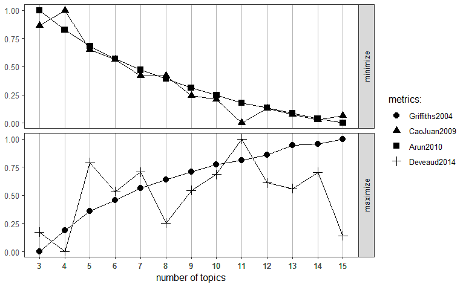

```r
FindTopicsNumber_plot(
  result
)
```

LDA modeling. Brace yourself. This section will consume your time a bit longer.

```r
library(topicmodels)

lda_model <- LDA(
  dtm,
  k = 5,
  control =
    list(seed=123)
)
```

Extracting themes with represented words.

```r
topic_terms <-
  terms(
    lda_model,
    30
  )

write.csv(topic_terms, "topic_terms.csv")
topic_terms
```

```
      Topic 1       Topic 2        Topic 3        Topic 4        Topic 5
 [1,] "simple"      "approach"     "learn"        "concept"      "teacher"
 [2,] "datum"       "experimental" "method"       "understand"   "model"
 [3,] "energy"      "energy"       "simple"       "design"       "year"
 [4,] "measurement" "light"        "time"         "datum"        "understand"
 [5,] "learn"       "time"         "activity"     "learn"        "time"
 [6,] "problem"     "university"   "system"       "material"     "object"
 [7,] "laboratory"  "science"      "example"      "model"        "method"
 [8,] "determine"   "course"       "measure"      "field"        "motion"
 [9,] "science"     "work"         "discuss"      "help"         "course"
[10,] "current"     "different"    "find"         "experimental" "relate"
[11,] "work"        "make"         "experimental" "science"      "scientific"
[12,] "make"        "analysis"     "measurement"  "physical"     "datum"
[13,] "force"       "project"      "law"          "group"        "law"
[14,] "motion"      "problem"      "datum"        "laboratory"   "may"
```

[output cut: 16 more lines]

Create Visualization

```r
topic_prob <-
  topicmodels::posterior(
    lda_model
  )$topics

df_abstract_clean <- df_clean |> filter(!is.na(AB))

topic_df <- cbind(df_abstract_clean, topic_prob)

rep_papers <- lapply(
  1:ncol(topic_terms),
  function(k){

    topic_name <- paste0(k)

    topic_df %>%
      arrange(desc(.data[[topic_name]])) %>%
      select(
        Topic = all_of(topic_name),
        TI_raw,
        AU2,
        PY
      ) %>%
      mutate(
        Topic_ID = paste0("Topic ", k)
      )
  }
)

rep_papers <- bind_rows(rep_papers)
```

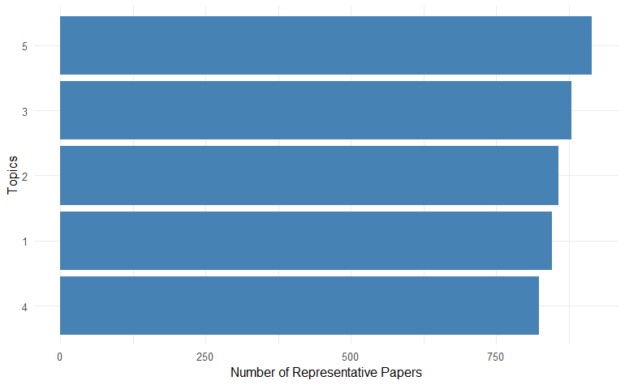

```r
topic_df2 <- data.frame(
  Topic = apply(topic_prob, 1, which.max)
)

topic_share <- table(
  topic_df2$Topic
)

topic_share <-
  as.data.frame(
    topic_share
  )

ggplot(
  topic_share,
  aes(
    reorder(
      Var1,
      Freq
    ),
    Freq
  )
)+ labs(x = "Topics", y = "Number of Representative Papers") +

geom_col(
  fill="steelblue"
)+

coord_flip()+
theme_minimal()
```

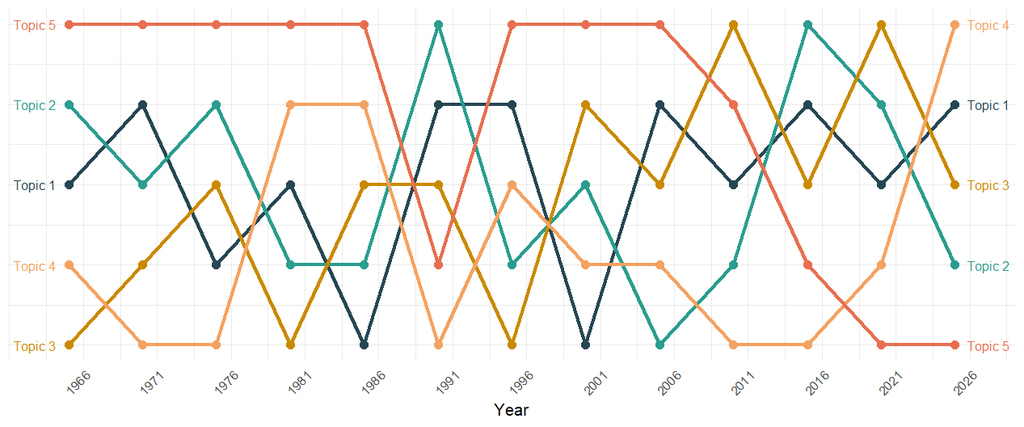

```r
library(ggrepel)

topic_prob <- topicmodels::posterior(
  lda_model
)$topics

topic_df$Topic <- apply(
  topic_prob,
  1,
  which.max
)

topic_df$Label <- c(
  "Topic 1",
  "Topic 2",
  "Topic 3",
  "Topic 4",
  "Topic 5"
)[topic_df$Topic]

topic_df <- topic_df %>%
  mutate(
    Period = floor(PY / 5) * 5
  )

topic_rank <- topic_df %>%
  count(
    Period,
    Label
  ) %>%
  group_by(Period) %>%
  mutate(
    Percent = n / sum(n) * 100,
    Rank = rank(
      -Percent,
      ties.method = "first"
    )
  )

redmonk_pal <- c(
  "Topic 1" = "#264653",
  "Topic 2" = "#2A9D8F",
  "Topic 3" = "#C98A00",
  "Topic 4" = "#F4A261",
  "Topic 5" = "#E76F51"
)

first_label <- topic_rank %>%
  group_by(Label) %>%
  filter(Period == min(Period))

last_label <- topic_rank %>%
  group_by(Label) %>%
  filter(Period == max(Period))

ggplot(
  topic_rank,
  aes(
    Period,
    Rank,
    group = Label,
    colour = Label
  )
) +
  geom_line(
    linewidth = 1.5
  ) +
  geom_point(
    size = 3
  ) +
  scale_x_continuous(
  breaks = seq(1966, 2026, by = 5)
  ) +
  scale_colour_manual(
    values = redmonk_pal
  ) +
  scale_y_reverse(
    breaks = 1:5
  ) +
  labs(
    y = NULL,
    x = "Year"
  ) +
  theme_minimal(base_size = 14) +
  theme(
    axis.text.x = element_text(
      angle = 45,
      hjust = 1
    ),
    axis.text.y = element_blank(),
    axis.ticks.y = element_blank()
  ) +
  geom_text_repel(
  data = first_label,
  aes(label = Label),
  direction = "y",
  hjust = 1,
  nudge_x = -1,
  segment.color = NA,
  show.legend = FALSE
  ) +
  geom_text_repel(
  data = last_label,
  aes(label = Label),
  direction = "y",
  hjust = 0,
  nudge_x = 1,
  segment.color = NA
  ) +
  theme(
  legend.position = "none"
  )
```

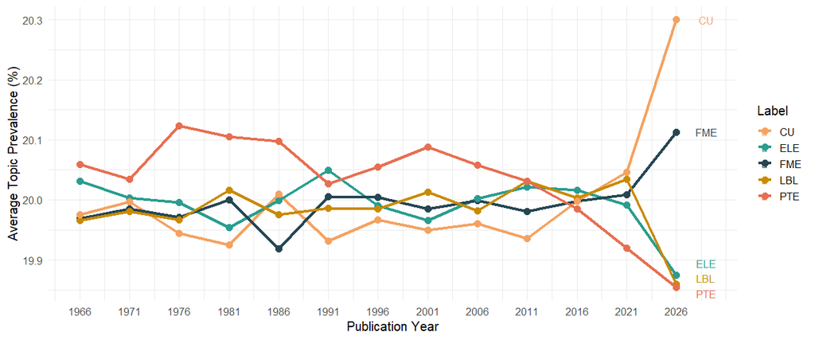

```r
library(tidyr)
library(dplyr)

gamma <- as.data.frame(topic_prob)

gamma$PY <- topic_df$PY

gamma_long <- gamma %>%
  mutate(
    Period = floor((PY - 1966) / 5) * 5 + 1966
  ) %>%
  pivot_longer(
    cols = -c(PY, Period),
    names_to = "Topic",
    values_to = "Gamma"
  )

topic_trend <- gamma_long %>%
  group_by(
    Period,
    Topic
  ) %>%
  summarise(
    Prevalence = mean(Gamma) * 100,
    .groups = "drop"
  )

topic_trend$Label <- c(
  "FME",
  "ELE",
  "LBL",
  "CU",
  "PTE"
)[as.numeric(topic_trend$Topic)]

last_label <- topic_trend %>%
  group_by(Label) %>%
  filter(Period == max(Period))

redmonk_pal <- c(
  "FME" = "#264653",
  "ELE" = "#2A9D8F",
  "LBL" = "#C98A00",
  "CU" = "#F4A261",
  "PTE" = "#E76F51"
)

ggplot(topic_trend,
  aes(Period,Prevalence,colour = Label)) +
  geom_line(linewidth = 1.5) +
  geom_point(size = 3) +
  scale_colour_manual(values = redmonk_pal) +
  scale_x_continuous(breaks = seq(1966, 2026, 5)) +
  labs(x = "Publication Year",
       y = "Average Topic Prevalence (%)") +
  theme_minimal(base_size = 14) +
  geom_text_repel(data = last_label, aes(label = Label), nudge_x = 3,
                  segment.color = NA, show.legend = TRUE)
```